# 1. 파이썬 기초

```python
import time
start_time = time.time()  # 측정 시작

end_time = time.time()  # 측정 종료
print("time:", end_time - start_time)  # 수행 시간 출력
```

[output not shown]

## 정수형, 실수형

```python
a = 0.3+0.6
print(a)

if a == 0.9:
    print(True)
else:
    print(False)
```

```
0.8999999999999999
False
```

```python
a = 0.3+0.6
print(round(a,4))   # 반올림 함수

if round(a,4) == 0.9:
    print(True)
else:
    print(False)
```

```
0.9
True
```

```python
a=7
b=3

# 나누기
print(a/b)

# 나머지
print(a%b)

# 몫
print(a//b)

# 거듭제곱
print(a**b)

# 제곱근
print(a**0.5)
```

```
2.3333333333333335
1
2
343
2.6457513110645907
```

## 리스트 (list)

```python
# 직접 데이터를 넣어 초기화
a = [1,2,3,4,5,6,7,8,9]
print(a)

# 네 번째 원소만 출력
print(a[3])

# 크기가 N이고, 모든 값이 0인 1차원 리스트 초기화
n = 10
a = [0]*n
print(a)
```

```
[1, 2, 3, 4, 5, 6, 7, 8, 9]
4
[0, 0, 0, 0, 0, 0, 0, 0, 0, 0]
```

```python
a = [1,2,3,4,5,6,7,8,9]

# 여덟 번째 원소만 출력
print(a[7])

# 뒤에서 첫 번쨰 원소 출력
print(a[-1])

# 뒤에서 세 번째 원소 출력
print(a[-3])

# 네 번째 원소 값 변경
a[3] = 7
print(a)
```

```
8
9
7
[1, 2, 3, 7, 5, 6, 7, 8, 9]
```

리스트의 인덱싱과 슬리이싱

```python
a = [1,2,3,4,5,6,7,8,9]

# 두 번째 원소부터 네 번째 원소까지
print(a[1:4])
```

```
[2, 3, 4]
```

리스트 컴프리헨션 (초기화하기 위한 간단한 방법)

```python
# 0부터 9까지의 수를 포함하는 리스트
array = [i for i in range(10)]  # range(10) : 0~9
print(array)
```

```
[0, 1, 2, 3, 4, 5, 6, 7, 8, 9]
```

```python
# 0부터 19까지의 수 중에서 홀수만 포함하는 리스트
array = [i for i in range(20) if i % 2 == 1]
print(array)

# 1부터 9까지의 수들의 제곱 값을 포함하는 리스트
array = [i * i for i in range(1,10)]
print(array)
```

```
[1, 3, 5, 7, 9, 11, 13, 15, 17, 19]
[1, 4, 9, 16, 25, 36, 49, 64, 81]
```

리스트 컴프리헨션을 사용하지 않은 일반적은 코드 (보다 복잡함)

```python
# 0부터 19까지의 수 중에서 홀수만 포함하는 리스트
array = []
for i in range(20):
    if i % 2 == 1:
        array.append(i)

print(array)
```

```
[1, 3, 5, 7, 9, 11, 13, 15, 17, 19]
```

리스트 컴프리헨션은 2차원 리스트를 초기화할 때 효과적으로 사용됨

```python
# N*M 크기의 2차원 리스트 초기화
n = 4
m = 3
array = [[0]*m for _ in range(n)]
print(array)
```

```
[[0, 0, 0], [0, 0, 0], [0, 0, 0], [0, 0, 0]]
```

```python
# 1부터 9까지의 자연수를 더하기
summary = 0
for i in range(1,10):
    summary += i
print(summary)
```

```
45
```

반복을 수행하되 반복을 위한 변수의 값을 무사히고자 할 때 언더바(_)를 사용함

```python
# "Hello World"를 5번 출력하기
for _ in range(5):
    print("Hello World")
```

```
Hello World
Hello World
Hello World
Hello World
Hello World
```

리스트 관련 기타 메서드

```python
a = [1,4,3]
print("기본 리스트: ",a)

# 리스트에 원소 삽입
a.append(2)
print("삽입: ",a)

# 오름차순 정렬
a.sort()
print("오름차순 정렬: ",a)

# 내림차순 정렬
a.sort(reverse = True)
print("내림차순 정렬: ",a)
```

```
기본 리스트:  [1, 4, 3]
삽입:  [1, 4, 3, 2]
오름차순 정렬:  [1, 2, 3, 4]
내림차순 정렬:  [4, 3, 2, 1]
```

```python
a = [4,3,2,1]

# 리스트 원소 뒤집기
a.reverse()
print("원소 뒤집기: ",a)

# 특정 인덱스에 데이터 추가
a.insert(2,3)
print("인덱스 2에 3 추가: ",a)

# 특정 값인 데이터 개수 세기
print("값이 3인 데이터 개수: ",a.count(3))

# 특정 값 데이터 삭제
a.remove(1)
print("값이 1인 데이터 삭제: ",a)
```

```
원소 뒤집기:  [1, 2, 3, 4]
인덱스 2에 3 추가:  [1, 2, 3, 3, 4]
값이 3인 데이터 개수:  2
값이 1인 데이터 삭제:  [2, 3, 3, 4]
```

리스트에서 특정 값을 가지는 원소를 모두 제거하기

```python
a = [1,2,3,4,5,5,5]
remove_set = {3,5} # 집합 자료형

# remove_list에 포함되지 않은 값만을 저장
result = [i for i in a if i not in remove_set]
print(result)
```

```
[1, 2, 4]
```

## 문자열 자료형 (변경 불가능)

```python
data = 'Hello World'
print(data)

data = "Don't you know \"Python\"?"
print(data)
```

```
Hello World
Don't you know "Python"?
```

```python
a = "Hello"
b = "World"
print(a+" "+b)

a = "String"
print(a*3)

a = "ABCDEF"
print(a[2:4])
```

```
Hello World
StringStringString
CD
```

```python
a[2] = 'a'  # error 발생
```

```
---------------------------------------------------------------------------
TypeError                                 Traceback (most recent call last)
<ipython-input-37-515d8c0bb2aa> in <module>
----> 1 a[2] = 'a'  # error 발생

TypeError: 'str' object does not support item assignment
```

## 튜플 자료형 (변경 불가능) (공간 효율적)

```python
a = (1,2,3,4,5,6,7,8,9)

# 네 번째 원소만 출력
print(a[3])

# 두 번째 원소부터 네 번째 원소까지
print(a[1:4])
```

```
4
(2, 3, 4)
```

```python
a = (1,2,3,4)
print(a)

a[2] = 7  # error
```

```
(1, 2, 3, 4)
```

```
---------------------------------------------------------------------------
TypeError                                 Traceback (most recent call last)
<ipython-input-39-edd4b911623b> in <module>
      2 print(a)
      3
----> 4 a[2] = 7  # error

TypeError: 'tuple' object does not support item assignment
```

### 튜플을 사용하면 좋은 경우

#### * 서로 다른 성질의 데이터를 묶어서 관리해야 할 때

```
최단 경로 알고리즘에서는 (비용, 노드번호)의 형태로 튜플 자료형을 자주 사용함
```

#### * 데이터의 나열을 해싱(Hashing)의 키 값으로 사용해야 할 때

```
튜플은 변경이 불가능하므로 리스트와 다르게 키 값으로 사용될 수 있음
```

#### * 리스트보다 메모리를 효율적으로 사용해야 할 때

## 사전(dictionary), 집합(set) 자료형

```python
data = dict()
data['사과'] = 'Apple'   # 사과 (key) , Apple (Value)
data['바나나'] = 'Banana'
data['코코넛'] = 'Coconut'

print(data)

if '사과' in data:
    print("'사과'를 키로 가지는 데이터가 존재합니다.")

# 키 데이터만 담은 리스트
key_list = data.keys()

# 값 데이터만 담은 리스트
value_list = data.values()

print(key_list)
print(value_list)

# 각 키에 따른 값을 하나씩 출력
for key in key_list:
    print(data[key])
```

```
{'사과': 'Apple', '바나나': 'Banana', '코코넛': 'Coconut'}
'사과'를 키로 가지는 데이터가 존재합니다.
dict_keys(['사과', '바나나', '코코넛'])
dict_values(['Apple', 'Banana', 'Coconut'])
Apple
Banana
Coconut
```

### 집합은 다음과 같은 특징이 있습니다.

#### * 중복을 허용하지 않습니다.

#### * 순서가 없습니다.

### 집합은 리스트 혹은 문자열을 이용해서 초기화할 수 있습니다.

#### * 이 때 set() 함수를 이용합니다.

### 혹은 중괄호({}) 안에 각 원소를 콤마(,)를 기준으로 구분하여 삽입함으로써 초기화 할 수 있습니다.

```python
# 집합 자료형 초기화 방법1
data = set([1,1,2,3,4,4,5])
print(data)

# 집합 자료형 초기화 방법2
data = {1,1,2,3,4,4,5}
print(data)

a = set([1,2,3,4,5])
b = set([3,4,5,6,7])

# 합집합
print(a|b)

# 교집합
print(a&b)

# 차집합
print(a-b)
```

```
{1, 2, 3, 4, 5}
{1, 2, 3, 4, 5}
{1, 2, 3, 4, 5, 6, 7}
{3, 4, 5}
{1, 2}
```

```python
data = set([1,2,3])
print(data)

# 새로운 원소 추가
data.add(4)
print(data)

# 새로운 원소 여러 개 추가
data.update([5,6])
print(data)

# 특정한 값을 갖는 원소 삭제
data.remove(3)
print(data)
```

```
{1, 2, 3}
{1, 2, 3, 4}
{1, 2, 3, 4, 5, 6}
{1, 2, 4, 5, 6}
```

#### 리스트나 튜플은 순서가 있기 때문에 인덱싱을 통해 자료형의 값을 얻을 수 있다.

#### 사전 자료형과 집합 자료형은 순서가 없기 때문에 인덱싱으로 값을 얻을 수 없다!

## 기본 입출력

#### input() 함수는 한 줄의 문자열을 입력 받는 함수

#### map() 함수는 리스트의 모든 원소에 각각 특정한 함수를 적용할 때 사용

```python
# 데이터의 개수 입력
n = int(input())
# 각 데이터를 공백을 기준으로 구분하여 입력
data = list(map(int, input().split()))

data.sort(reverse=True)  # 내림차순 정렬
print(data)
```

```
5
65 90 75 34 99
[99, 90, 75, 65, 34]
```

```python
a, b, c = map(int, input().split())
print(a, b, c)
```

```
8 3 9
8 3 9
```

#### 빠르게 입력 받기

##### * 파이썬의 경우 sys.stdin.readline() 메서드를 이용

##### * 단, 입력 후 엔터가 줄 바꿈 기호로 입력되므로 retrip() 메서드를 함께 사용

```python
import sys

# 문자열 입력 받기
data = sys.stdin.readline().rstrip()
print(data)
```

```python
# 출력할 변수들
a = 1
b = 2
print(a, b)
print(7, end=" ")   # 줄 바꿈 발생하지 않도록 end=" " 사용
print(8, end=" ")

# 출력할 변수
answer = 7
print(" 정답은 " + str(answer) + "입니다.")
```

```
1 2
7 8  정답은 7입니다.
```

#### f-string (파이썬 3.6부터 사용 가능)

```python
answer = 7
print(f"정답은 {answer}입니다.")")
```

[output not shown]

## 조건문

```python
x = 15

if x >= 10:
    print("x >= 10")

if x >= 0:
    print("x >= 0")

if x >= 30:
    print("x >= 30")
```

```
x >= 10
x >= 0
```

### 들여쓰기 (코드의 블록을 들여쓰기로 지정)

```python
score = 85

if score >= 70:
    print('성적이 70점 이상입니다.')
    if score >= 90:
        print('우수한 성적입니다.')

else:
    print('성적이 70점 미만입니다.')
    print('조금 더 분발하세요.')

print('프로그램을 종료합니다.')
```

```
성적이 70점 이상입니다.
프로그램을 종료합니다.
```

#### if 조건문 1:

> 조건문 1이 True일 때 실행되는 코드

#### elif 조건문 2:

> 조건문 1에 해당하지 않고, 조건문 2가 True일 때 실행되는 코드

#### else:

> 위의 모든 조건문이 모두 True 값이 아닐 때 실행되는 코드

```python
a = -5

if a >= 0:
    print("a >= 0")
elif a >= -10:
    print("0 > a >= -10")
else:
    print("-10 > a")
```

```
0 > a >= -10
```

### 성적 구간에 따른 학점 출력 예제

```python
score = 85

if score >= 90:
    print("학점: A")
elif score >= 80:      # 90점 미만일 때만 수행됨
    print("학점: B")
elif score >= 70:
    print("학점: C")
else:
    print("학점: F")
```

```
학점: B
```

```python
a = 15

if a <=20 and a >= 0:    # 논리 연산자
    print('Yes')
```

```
Yes
```

### 파이썬의 pass 키워드 (아무것도 처리하고 싶지 않을 때 사용)

```python
score = 85

if score >= 80:
    pass   # 나중에 작성할 소스코드
else:
    print('성적이 80점 미만입니다.')

print('프로그램을 종료합니다.')
```

```
프로그램을 종료합니다.
```

### 조건문의 간소화

```python
score = 85

if score >= 80: result = 'Success'    # 조건문에서 실행될 소스코드가 한 줄인 경우, 줄 바꿈 하지 않아도 됨
else: result = 'Fail'

print(result)
```

```
Success
```

```python
score = 85
result = "Success" if score >= 80 else "Fail"   # 조건부 표현식

print(result)
```

```
Success
```

```python
x = 15
if 0 < x < 20:     # if x > 0 and x < 20: 이 일반적인 스타일 (왼쪽 식은 파이썬에서만 허용하는 문법)
    print("x는 0 이상 20 미만의 수 입니다.")
```

```
x는 0 이상 20 미만의 수 입니다.
```

## 반복문 (while, for문)

```python
i = 1
result = 0

# i가 9보다 작거나 같을 때 아래 코드를 반복적으로 실행
while i <= 9:
    result += i
    i += 1

print(result)
```

```
45
```

### 1부터 9까지 홀수의 합 구하기 예제 (while문)

```python
i = 1
result = 0

# i가 9보다 작거나 같을 때 아래 코드를 반복적으로 실행
while i <= 9:
    if i % 2 ==1:
        result += i
    i += 1

print(result)
```

```
25
```

for 변수 in 리스트:

> 실행할 소스코드

```python
array = [9,8,7,6,5]

for x in array:
    print(x)
```

```
9
8
7
6
5
```

```python
result = 0

# i는 1부터 9까지의 모든 값을 순회
for i in range(1,10):
    result += i       # range(시작 값, 끝 값+1)

print(result)
```

```
45
```

### 1부터 9까지 홀수의 합 구하기 예제 (for문)

```python
result = 0

for i in range(1,10):
    if i % 2 == 0:
        continue     # 아래의 남은 반복문 코드는 건너뜀
    result += i

print(result)
```

```
25
```

```python
i = 1

while True:
    print("현재 i의 값: ",i)
    if i == 5:
        break   # 반복문 탈출
    i += 1
```

```
현재 i의 값:  1
현재 i의 값:  2
현재 i의 값:  3
현재 i의 값:  4
현재 i의 값:  5
```

### 학생들의 합격 여부 판단 예제 1) 점수가 80점만 넘으면 합격

```python
scores = [90, 85, 77, 65, 97]

for i in range(5):
    if scores[i] >= 80:
        print(i+1, "번 학생은 합격입니다.")
```

```
1 번 학생은 합격입니다.
2 번 학생은 합격입니다.
5 번 학생은 합격입니다.
```

### 학생들의 합격 여부 판단 예제 2) 특정 번호의 학생은 제외하기

```python
scores = [90, 85, 77, 65, 97]
cheating_student_list = {2, 4}

for i in range(5):
    if i+1 in cheating_student_list:
        continue
    if scores[i] >= 80:
        print(i+1, "번 학생은 합격입니다.")
```

```
1 번 학생은 합격입니다.
5 번 학생은 합격입니다.
```

### 중첩된 반복문 : 구구단 예제

```python
for i in range(2,10):
    for j in range(1,10):
        print(i, "X", j, "=", i*j)
    print()
```

```
2 X 1 = 2
2 X 2 = 4
2 X 3 = 6
2 X 4 = 8
2 X 5 = 10
2 X 6 = 12
2 X 7 = 14
2 X 8 = 16
2 X 9 = 18

3 X 1 = 3
3 X 2 = 6
3 X 3 = 9
3 X 4 = 12
3 X 5 = 15
```

[output cut: 64 more lines]

## 함수 (function)

def 함수명(매개변수) :

> 실행할 소스코드  
> return 반환 값

#### 더하기 함수 예시 1)

```python
def add(a, b):
    return a+b

print(add(3,7))
```

```
10
```

#### 더하기 함수 예시2)

```python
def add(a, b):
    print('함수의 결과:', a+b)

add(3,7)
```

```
함수의 결과: 10
```

### global 키워드

#### global 키워드로 변수를 지정하면 해당 함수에서는 지역 변수를 만들지 않고, 함수 바깥에 선언된 변수를 바로 참조하게 됨

```python
a = 0

def func():
    global a
    a += 1

for i in range(10):
    func()

print(a)
```

```
10
```

### 지역변수와 전역변수의 차이

```python
array = [1,2,3,4,5]

def func():
    array = [3,4,5]
    array.append(6)   # 지역 변수에 초점
    print(array)

func()
print(array)   # 전역 변수에 초점
```

```
[3, 4, 5, 6]
[1, 2, 3, 4, 5]
```

### 여러 개의 반환 값

#### 파이썬에서 함수는 여러 개의 반환 값을 가질 수 있다.

```python
def operator(a, b):
    add_var = a + b
    subtract_var = a - b
    multiply_var = a * b
    divide_var = a / b
    return add_var, subtract_var, multiply_var, divide_var

a, b, c, d = operator(7,3)
print(a, b, c, d)
```

```
10 4 21 2.3333333333333335
```

### 람다 표현식 (함수를 간단하게 작성 가능)

```python
print((lambda a, b : a + b)(3,7))
```

```
10
```

```python
array = [('홍길동', 50), ('이순신', 32), ('아무개', 74)]

def my_key(x):
    return x[1]

print(sorted(array, key=my_key))  # 오름차순 정렬

print(sorted(array, key=lambda x: x[1]))
```

```
[('이순신', 32), ('홍길동', 50), ('아무개', 74)]
[('이순신', 32), ('홍길동', 50), ('아무개', 74)]
```

#### 여러 개의 리스트에 람다 표현식 적용 예시

```python
list1 = [1,2,3,4,5]
list2 = [6,7,8,9,10]

result = map(lambda a, b: a+b, list1, list2)

print(list(result))
```

```
[7, 9, 11, 13, 15]
```

# 2. Numpy

```python
import numpy as np
```

```python
data = [[1,2,3], [4,5,6], [7,8,9]]

a = np.array(data)
a
```

```
array([[1, 2, 3],
       [4, 5, 6],
       [7, 8, 9]])
```

```python
a.dtype
```

```
dtype('int32')
```

```python
a.shape
```

```
(3, 3)
```

```python
type(a)
```

```
numpy.ndarray
```

```python
a = a.astype(np.float32)  # a = a.astype('float32')
a
```

```
array([[1., 2., 3.],
       [4., 5., 6.],
       [7., 8., 9.]], dtype=float32)
```

```python
a[0][1]
```

```
2.0
```

```python
a[0]
```

```
array([1., 2., 3.], dtype=float32)
```

```python
np.arange(1, 10, 2)
```

```
array([1, 3, 5, 7, 9])
```

```python
np.arange(1, 10).reshape(3,3)
```

```
array([[1, 2, 3],
       [4, 5, 6],
       [7, 8, 9]])
```

```python
np.arange(1, 13).reshape(3,2,2)
```

```
array([[[ 1,  2],
        [ 3,  4]],

       [[ 5,  6],
        [ 7,  8]],

       [[ 9, 10],
        [11, 12]]])
```

```python
np.nan * 10
```

```
nan
```

```python
a[0][1] = np.nan  # int에는 np.nan 사용 못함. float 에서만 사용 가능
```

```python
a
```

```
array([[ 1., nan,  3.],
       [ 4.,  5.,  6.],
       [ 7.,  8.,  9.]], dtype=float32)
```

```python
a = np.linspace(1, 10, 20)  # 1 부터 10까지 20개 생성
a
```

```
array([ 1.        ,  1.47368421,  1.94736842,  2.42105263,  2.89473684,
        3.36842105,  3.84210526,  4.31578947,  4.78947368,  5.26315789,
        5.73684211,  6.21052632,  6.68421053,  7.15789474,  7.63157895,
        8.10526316,  8.57894737,  9.05263158,  9.52631579, 10.        ])
```

```python
array = [0,1,2,3,4,5,6]
print(array)
np.array(array)   #numpy array 형태로 바꿈
```

```
[0, 1, 2, 3, 4, 5, 6]
```

```
array([0, 1, 2, 3, 4, 5, 6])
```

### 연산

```python
data = np.arange(1, 10).reshape(3,3)
data
```

```
array([[1, 2, 3],
       [4, 5, 6],
       [7, 8, 9]])
```

```python
data + data
```

```
array([[ 2,  4,  6],
       [ 8, 10, 12],
       [14, 16, 18]])
```

```python
[1,2,3] + [4,5,6]  # list 에서의 + 는 연산이 아닌 연결임
```

```
[1, 2, 3, 4, 5, 6]
```

```python
data * data   # 행렬의 연산이 아닌 원소들 끼리의 곱과 나누기임
```

```
array([[ 1,  4,  9],
       [16, 25, 36],
       [49, 64, 81]])
```

```python
data / data
```

```
array([[1., 1., 1.],
       [1., 1., 1.],
       [1., 1., 1.]])
```

```python
np.dot(data, data)  # 행렬의 곱
```

```
array([[ 30,  36,  42],
       [ 66,  81,  96],
       [102, 126, 150]])
```

```python
data@data  # 행렬의 곱
```

```
array([[ 30,  36,  42],
       [ 66,  81,  96],
       [102, 126, 150]])
```

```python
arr4 = np.array([
    [1,2,3],
    [4,5,6]
], dtype = np.float64)

arr5 = np.array([
    [7,8,9],
    [10,11,12]
], dtype = np.float64)

# 사칙연산 출력
print("arr4 + arr5 = ")
print(arr4 + arr5, "\n")
print("arr4 - arr5 = ")
print(arr4 - arr5, "\n")
print("arr4 * arr5 = ")
print(arr4 * arr5, "\n")
print("arr4 / arr5 = ")
print(arr4 / arr5, "\n")
```

```
arr4 + arr5 =
[[ 8. 10. 12.]
 [14. 16. 18.]]

arr4 - arr5 =
[[-6. -6. -6.]
 [-6. -6. -6.]]

arr4 * arr5 =
[[ 7. 16. 27.]
 [40. 55. 72.]]

arr4 / arr5 =
[[0.14285714 0.25       0.33333333]
 [0.4        0.45454545 0.5       ]]
```

### 차원

```python
# 0차원 : 스칼라
a = np.array(1)
a
#a.shape
#a.ndim
```

```
array(1)
```

```python
# 1차원 : 벡터
a = np.array([1])
a
#a.shape
#a.ndim
```

```
array([1])
```

```python
# 1차원 : 벡터
a = np.array([1,2,3,4,5])
a
#a.shape  # (5,)
#a.ndim  # 1
```

```
array([1, 2, 3, 4, 5])
```

```python
# 2차원 : 매트릭스
a = np.array([[1,2,3], [4,5,6]])
a
#a.shape  # (2,3)
#a.ndim # 2
```

```
array([[1, 2, 3],
       [4, 5, 6]])
```

```python
# 3차원 : 3차원 이상의 다차원의 행렬을 Tersor
a = np.array([[[1,2], [3,4], [5,6]], [[7,8], [9,10], [11,12]]])
a
#a.shape  # (2,3,2)
#a.ndim  # 3
```

```
array([[[ 1,  2],
        [ 3,  4],
        [ 5,  6]],

       [[ 7,  8],
        [ 9, 10],
        [11, 12]]])
```

### matrix의 유형

```python
a = np.arange(12).reshape(2,3,2)
a
```

```
array([[[ 0,  1],
        [ 2,  3],
        [ 4,  5]],

       [[ 6,  7],
        [ 8,  9],
        [10, 11]]])
```

```python
b = np.ones(12).reshape(2,3,2)
b
```

```
array([[[1., 1.],
        [1., 1.],
        [1., 1.]],

       [[1., 1.],
        [1., 1.],
        [1., 1.]]])
```

```python
c = np.zeros(12).reshape(2,3,2)
c
```

```
array([[[0., 0.],
        [0., 0.],
        [0., 0.]],

       [[0., 0.],
        [0., 0.],
        [0., 0.]]])
```

```python
d = np.eye(3)   # 단위 행렬
d
```

```
array([[1., 0., 0.],
       [0., 1., 0.],
       [0., 0., 1.]])
```

```python
e = np.zeros([3,4])
e
```

```
array([[0., 0., 0., 0.],
       [0., 0., 0., 0.],
       [0., 0., 0., 0.]])
```

```python
e = np.zeros([3,4,2])
e
```

```
array([[[0., 0.],
        [0., 0.],
        [0., 0.],
        [0., 0.]],

       [[0., 0.],
        [0., 0.],
        [0., 0.],
        [0., 0.]],

       [[0., 0.],
        [0., 0.],
        [0., 0.],
        [0., 0.]]])
```

```python
f = np.empty([2,3])
f
```

```
array([[0., 0., 0.],
       [0., 0., 0.]])
```

```python
g = np.full((3,4,),1000)
g
```

```
array([[1000, 1000, 1000, 1000],
       [1000, 1000, 1000, 1000],
       [1000, 1000, 1000, 1000]])
```

```python
h = np.linspace(2, 10, 6)
h
```

```
array([ 2. ,  3.6,  5.2,  6.8,  8.4, 10. ])
```

### 집계 함수

```python
a = np.arange(10).reshape(2,5)
a
```

```
array([[0, 1, 2, 3, 4],
       [5, 6, 7, 8, 9]])
```

```python
a[0][0] = 100
a
```

```
array([[100,   1,   2,   3,   4],
       [  5,   6,   7,   8,   9]])
```

```python
a[0,1] = 1000
a
```

```
array([[ 100, 1000,    2,    3,    4],
       [   5,    6,    7,    8,    9]])
```

```python
np.mean(a)
```

```
114.4
```

```python
np.median(a)
```

```
6.5
```

```python
np.std(a)
```

```
296.5485457728633
```

```python
np.var(a)
```

```
87941.04
```

```python
np.sum(a)
```

```
1144
```

```python
sum(a)
```

```
array([ 105, 1006,    9,   11,   13])
```

```python
a
```

```
array([[ 100, 1000,    2,    3,    4],
       [   5,    6,    7,    8,    9]])
```

```python
np.sum(a, axis=0)  # 열 별로 합계
```

```
array([ 105, 1006,    9,   11,   13])
```

```python
np.sum(a, axis=1)  # 행 별로 합계
```

```
array([1109,   35])
```

```python
np.max(a)
```

```
1000
```

```python
np.min(a)
```

```
2
```

# 3. Pandas

```python
import pandas as pd
import numpy as np
```

```python
data = np.arange(0,50,10)
data
```

```
array([ 0, 10, 20, 30, 40])
```

```python
a = pd.Series(data, index=['a','b','c','d','e'])
a
```

```
a     0
b    10
c    20
d    30
e    40
dtype: int32
```

```python
b = pd.Series(data)
b
```

```
0     0
1    10
2    20
3    30
4    40
dtype: int32
```

```python
a['b']
```

```
10
```

```python
a.loc['b']
```

```
10
```

```python
a.iloc[1]   # index_location
```

```
10
```

### 산술연산

```python
a
```

```
a     0
b    10
c    20
d    30
e    40
dtype: int32
```

```python
a + 10
a - 10
a * 10
a ** 2
a / 5
a // 5
a % 3
```

```
a    0
b    1
c    2
d    0
e    1
dtype: int32
```

```python
a
```

```
a     0
b    10
c    20
d    30
e    40
dtype: int32
```

```python
a > 15
```

```
a    False
b    False
c     True
d     True
e     True
dtype: bool
```

```python
a[a > 15]
```

```
c    20
d    30
e    40
dtype: int32
```

### 집계함수

```python
a
```

```
a     0
b    10
c    20
d    30
e    40
dtype: int32
```

```python
a.add(100)
```

```
a    100
b    110
c    120
d    130
e    140
dtype: int32
```

```python
a.sub(100)
```

```
a   -100
b    -90
c    -80
d    -70
e    -60
dtype: int32
```

```python
a.mul(100)
```

```
a       0
b    1000
c    2000
d    3000
e    4000
dtype: int32
```

```python
a.div(100)
```

```
a    0.0
b    0.1
c    0.2
d    0.3
e    0.4
dtype: float64
```

```python
a.mod(3)
```

```
a    0
b    1
c    2
d    0
e    1
dtype: int32
```

```python
a.min()
```

```
0
```

```python
a.max()
```

```
40
```

```python
a.sum()
```

```
100
```

```python
a.mean()
```

```
20.0
```

```python
a.median()
```

```
20.0
```

```python
a.std()
```

```
15.811388300841896
```

```python
a.var()
```

```
250.0
```

### DataFrame

```python
rawData = np.random.randint(50, 100, size = (4,3))
rawData
```

```
array([[50, 92, 70],
       [72, 99, 78],
       [92, 60, 82],
       [57, 72, 61]])
```

```python
df = pd.DataFrame(rawData,
                  index = ['1반', '2반', '1반', '2반'],
                  columns = ['국', '영', '수'])
df
```

|  | 국 | 영 | 수 |
| --- | --- | --- | --- |
| 1반 | 50 | 92 | 70 |
| 2반 | 72 | 99 | 78 |
| 1반 | 92 | 60 | 82 |
| 2반 | 57 | 72 | 61 |

```python
#df[0]   # Error
df['국']
```

```
1반    50
2반    72
1반    92
2반    57
Name: 국, dtype: int32
```

```python
df
```

|  | 국 | 영 | 수 |
| --- | --- | --- | --- |
| 1반 | 50 | 92 | 70 |
| 2반 | 72 | 99 | 78 |
| 1반 | 92 | 60 | 82 |
| 2반 | 57 | 72 | 61 |

```python
df['평균'] = round((df['국'] + df['영'] + df['수'])/3 , 2)
df
```

|  | 국 | 영 | 수 | 평균 |
| --- | --- | --- | --- | --- |
| 1반 | 50 | 92 | 70 | 70.67 |
| 2반 | 72 | 99 | 78 | 83.00 |
| 1반 | 92 | 60 | 82 | 78.00 |
| 2반 | 57 | 72 | 61 | 63.33 |

```python
df['na'] = np.nan
df
```

|  | 국 | 영 | 수 | 평균 | na |
| --- | --- | --- | --- | --- | --- |
| 1반 | 50 | 92 | 70 | 70.67 | NaN |
| 2반 | 72 | 99 | 78 | 83.00 | NaN |
| 1반 | 92 | 60 | 82 | 78.00 | NaN |
| 2반 | 57 | 72 | 61 | 63.33 | NaN |

```python
del df['na']  # 결측치 제거
df
```

|  | 국 | 영 | 수 | 평균 |
| --- | --- | --- | --- | --- |
| 1반 | 50 | 92 | 70 | 70.67 |
| 2반 | 72 | 99 | 78 | 83.00 |
| 1반 | 92 | 60 | 82 | 78.00 |
| 2반 | 57 | 72 | 61 | 63.33 |

```python
df[df.평균 > 75]
```

|  | 국 | 영 | 수 | 평균 |
| --- | --- | --- | --- | --- |
| 2반 | 72 | 99 | 78 | 83.0 |
| 1반 | 92 | 60 | 82 | 78.0 |

```python
df = df.drop(['평균'], axis='columns')
df
```

|  | 국 | 영 | 수 |
| --- | --- | --- | --- |
| 1반 | 50 | 92 | 70 |
| 2반 | 72 | 99 | 78 |
| 1반 | 92 | 60 | 82 |
| 2반 | 57 | 72 | 61 |

### 결측값 처리

```python
df = df.astype('float64')
df
```

|  | 국 | 영 | 수 |
| --- | --- | --- | --- |
| 1반 | 50.0 | 92.0 | 70.0 |
| 2반 | 72.0 | 99.0 | 78.0 |
| 1반 | 92.0 | 60.0 | 82.0 |
| 2반 | 57.0 | 72.0 | 61.0 |

```python
df['수'][2] = np.nan
df
```

|  | 국 | 영 | 수 |
| --- | --- | --- | --- |
| 1반 | 50.0 | 92.0 | 70.0 |
| 2반 | 72.0 | 99.0 | 78.0 |
| 1반 | 92.0 | 60.0 | NaN |
| 2반 | 57.0 | 72.0 | 61.0 |

```python
df.dropna(axis=0)  # row 단위로 제거됨
```

|  | 국 | 영 | 수 |
| --- | --- | --- | --- |
| 1반 | 50.0 | 92.0 | 70.0 |
| 2반 | 72.0 | 99.0 | 78.0 |
| 2반 | 57.0 | 72.0 | 61.0 |

```python
df   # df.dropna 를 써도 원본이 보존됨
```

|  | 국 | 영 | 수 |
| --- | --- | --- | --- |
| 1반 | 50.0 | 92.0 | 70.0 |
| 2반 | 72.0 | 99.0 | 78.0 |
| 1반 | 92.0 | 60.0 | NaN |
| 2반 | 57.0 | 72.0 | 61.0 |

```python
df.dropna(axis=0, inplace=True)   # 원본이 수정됨
df
```

|  | 국 | 영 | 수 |
| --- | --- | --- | --- |
| 1반 | 50.0 | 92.0 | 70.0 |
| 2반 | 72.0 | 99.0 | 78.0 |
| 2반 | 57.0 | 72.0 | 61.0 |

```python
df = pd.DataFrame(rawData,
                  index = ['1반', '2반', '1반', '2반'],
                  columns = ['국', '영', '수'])
df
```

|  | 국 | 영 | 수 |
| --- | --- | --- | --- |
| 1반 | 50 | 92 | 70 |
| 2반 | 72 | 99 | 78 |
| 1반 | 92 | 60 | 82 |
| 2반 | 57 | 72 | 61 |

```python
df = df.astype('float64')
df['수'][2] = np.nan
df
```

|  | 국 | 영 | 수 |
| --- | --- | --- | --- |
| 1반 | 50.0 | 92.0 | 70.0 |
| 2반 | 72.0 | 99.0 | 78.0 |
| 1반 | 92.0 | 60.0 | NaN |
| 2반 | 57.0 | 72.0 | 61.0 |

```python
df.dropna(axis=1)  # column 단위로 제거됨
```

|  | 국 | 영 |
| --- | --- | --- |
| 1반 | 50.0 | 92.0 |
| 2반 | 72.0 | 99.0 |
| 1반 | 92.0 | 60.0 |
| 2반 | 57.0 | 72.0 |

```python
df.fillna('hello')
```

|  | 국 | 영 | 수 |
| --- | --- | --- | --- |
| 1반 | 50.0 | 92.0 | 70 |
| 2반 | 72.0 | 99.0 | 78 |
| 1반 | 92.0 | 60.0 | hello |
| 2반 | 57.0 | 72.0 | 61 |

```python
df.fillna(0)
```

|  | 국 | 영 | 수 |
| --- | --- | --- | --- |
| 1반 | 50.0 | 92.0 | 70.0 |
| 2반 | 72.0 | 99.0 | 78.0 |
| 1반 | 92.0 | 60.0 | 0.0 |
| 2반 | 57.0 | 72.0 | 61.0 |

```python
df.fillna(df.mean())   # na를 평균으로 대체함
```

|  | 국 | 영 | 수 |
| --- | --- | --- | --- |
| 1반 | 50.0 | 92.0 | 70.000000 |
| 2반 | 72.0 | 99.0 | 78.000000 |
| 1반 | 92.0 | 60.0 | 69.666667 |
| 2반 | 57.0 | 72.0 | 61.000000 |

### Multi-Index

```python
df
```

|  | 국 | 영 | 수 |
| --- | --- | --- | --- |
| 1반 | 50.0 | 92.0 | 70.0 |
| 2반 | 72.0 | 99.0 | 78.0 |
| 1반 | 92.0 | 60.0 | NaN |
| 2반 | 57.0 | 72.0 | 61.0 |

```python
df.T
```

|  | 1반 | 2반 | 1반 | 2반 |
| --- | --- | --- | --- | --- |
| 국 | 50.0 | 72.0 | 92.0 | 57.0 |
| 영 | 92.0 | 99.0 | 60.0 | 72.0 |
| 수 | 70.0 | 78.0 | NaN | 61.0 |

```python
df.index = [['1학년','1학년','2학년','2학년'], ['1반','2반','1반','2반']]
df
```

|  |  | 국 | 영 | 수 |
| --- | --- | --- | --- | --- |
| 1학년 | 1반 | 50.0 | 92.0 | 70.0 |
|  | 2반 | 72.0 | 99.0 | 78.0 |
| 2학년 | 1반 | 92.0 | 60.0 | NaN |
|  | 2반 | 57.0 | 72.0 | 61.0 |

```python
df.columns = [['언어','언어','수리'], ['국','영','수']]
df
```

|  |  | 언어 국 | 언어 영 | 수리 수 |
| --- | --- | --- | --- | --- |
| 1학년 | 1반 | 50.0 | 92.0 | 70.0 |
|  | 2반 | 72.0 | 99.0 | 78.0 |
| 2학년 | 1반 | 92.0 | 60.0 | NaN |
|  | 2반 | 57.0 | 72.0 | 61.0 |

```python
df['언어']
```

|  |  | 국 | 영 |
| --- | --- | --- | --- |
| 1학년 | 1반 | 50.0 | 92.0 |
|  | 2반 | 72.0 | 99.0 |
| 2학년 | 1반 | 92.0 | 60.0 |
|  | 2반 | 57.0 | 72.0 |

```python
df['언어']['국']
```

```
1학년  1반    50.0
     2반    72.0
2학년  1반    92.0
     2반    57.0
Name: 국, dtype: float64
```

```python
df.iloc[0]
```

```
언어  국    50.0
    영    92.0
수리  수    70.0
Name: (1학년, 1반), dtype: float64
```

```python
df.loc['1학년']
```

|  | 언어 국 | 언어 영 | 수리 수 |
| --- | --- | --- | --- |
| 1반 | 50.0 | 92.0 | 70.0 |
| 2반 | 72.0 | 99.0 | 78.0 |

```python
df.loc['1학년'].loc['1반']
```

```
언어  국    50.0
    영    92.0
수리  수    70.0
Name: 1반, dtype: float64
```

### 데이터 사전 분석

```python
df
```

|  |  | 언어 국 | 언어 영 | 수리 수 |
| --- | --- | --- | --- | --- |
| 1학년 | 1반 | 50.0 | 92.0 | 70.0 |
|  | 2반 | 72.0 | 99.0 | 78.0 |
| 2학년 | 1반 | 92.0 | 60.0 | NaN |
|  | 2반 | 57.0 | 72.0 | 61.0 |

```python
df.info()
```

```
<class 'pandas.core.frame.DataFrame'>
MultiIndex: 4 entries, ('1학년', '1반') to ('2학년', '2반')
Data columns (total 3 columns):
 #   Column   Non-Null Count  Dtype
---  ------   --------------  -----
 0   (언어, 국)  4 non-null      float64
 1   (언어, 영)  4 non-null      float64
 2   (수리, 수)  3 non-null      float64
dtypes: float64(3)
memory usage: 328.0+ bytes
```

```python
df.head()
```

|  |  | 언어 국 | 언어 영 | 수리 수 |
| --- | --- | --- | --- | --- |
| 1학년 | 1반 | 50.0 | 92.0 | 70.0 |
|  | 2반 | 72.0 | 99.0 | 78.0 |
| 2학년 | 1반 | 92.0 | 60.0 | NaN |
|  | 2반 | 57.0 | 72.0 | 61.0 |

```python
df.tail()
```

|  |  | 언어 국 | 언어 영 | 수리 수 |
| --- | --- | --- | --- | --- |
| 1학년 | 1반 | 50.0 | 92.0 | 70.0 |
|  | 2반 | 72.0 | 99.0 | 78.0 |
| 2학년 | 1반 | 92.0 | 60.0 | NaN |
|  | 2반 | 57.0 | 72.0 | 61.0 |

```python
df.dtypes
```

```
언어  국    float64
    영    float64
수리  수    float64
dtype: object
```

```python
df.describe()
```

|  | 언어 국 | 언어 영 | 수리 수 |
| --- | --- | --- | --- |
| count | 4.000000 | 4.000000 | 3.000000 |
| mean | 67.750000 | 80.750000 | 69.666667 |
| std | 18.589872 | 17.951323 | 8.504901 |
| min | 50.000000 | 60.000000 | 61.000000 |
| 25% | 55.250000 | 69.000000 | 65.500000 |
| 50% | 64.500000 | 82.000000 | 70.000000 |
| 75% | 77.000000 | 93.750000 | 74.000000 |
| max | 92.000000 | 99.000000 | 78.000000 |

```python
df.isnull()   # True : 결측치 존재
```

|  |  | 언어 국 | 언어 영 | 수리 수 |
| --- | --- | --- | --- | --- |
| 1학년 | 1반 | False | False | False |
|  | 2반 | False | False | False |
| 2학년 | 1반 | False | False | True |
|  | 2반 | False | False | False |

```python
df.isnull().sum()  # 결측치 갯수
```

```
언어  국    0
    영    0
수리  수    1
dtype: int64
```

### 값의 연결

```python
a = pd.DataFrame(np.arange(1,10).reshape(3,3))
a
```

|  | 0 | 1 | 2 |
| --- | --- | --- | --- |
| 0 | 1 | 2 | 3 |
| 1 | 4 | 5 | 6 |
| 2 | 7 | 8 | 9 |

```python
b = pd.Series(np.arange(10,40,10))
b
```

```
0    10
1    20
2    30
dtype: int32
```

```python
pd.concat([a,b],axis=1)
```

|  | 0 | 1 | 2 | 0 |
| --- | --- | --- | --- | --- |
| 0 | 1 | 2 | 3 | 10 |
| 1 | 4 | 5 | 6 | 20 |
| 2 | 7 | 8 | 9 | 30 |

```python
pd.concat([a,b], axis=1, ignore_index=True)
```

|  | 0 | 1 | 2 | 3 |
| --- | --- | --- | --- | --- |
| 0 | 1 | 2 | 3 | 10 |
| 1 | 4 | 5 | 6 | 20 |
| 2 | 7 | 8 | 9 | 30 |

```python
a.append(b, ignore_index=True)
```

|  | 0 | 1 | 2 |
| --- | --- | --- | --- |
| 0 | 1 | 2 | 3 |
| 1 | 4 | 5 | 6 |
| 2 | 7 | 8 | 9 |
| 3 | 10 | 20 | 30 |

# 4. Matplotlib 사용법

```python
#%matplotlib inline
import matplotlib.pyplot as plt
```

#### 간단한 직선 그래프 그리기

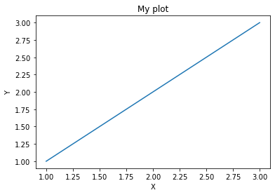

```python
x = [1,2,3]
y = [1,2,3]
plt.plot(x, y)
plt.title("My plot")
plt.xlabel("X")
plt.ylabel("Y")
plt.show()
```

#### 그래프 저장하기 (1)

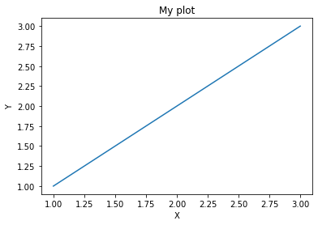

```python
import matplotlib.pyplot as plt
x = [1,2,3]
y = [1,2,3]
plt.plot(x, y)
plt.title("My plot")
plt.xlabel("X")
plt.ylabel("Y")
plt.savefig('picture.png')
```

#### 그래프 저장하기 (2)

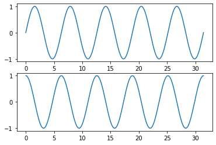

```python
import matplotlib.pyplot as plt
import numpy as np

x = np.linspace(0, np.pi * 10, 500)  # pi*10 너비에, 500개의 점을 균일하게 찍기
fig, axes = plt.subplots(2, 1)  # 2개의 그래프가 들어가는 Figure 생성
axes[0].plot(x, np.sin(x))
axes[1].plot(x, np.cos(x))
fig.savefig("sin&cos.png")
```

#### 선 그래프 그리기 (1)

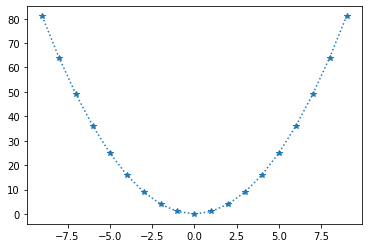

```python
import matplotlib.pyplot as plt
import numpy as np

x = np.arange(-9,10)
y = x ** 2
# 라인 스타일로는 '-',':','-.','--' 등이 사용가능함
plt.plot(x, y, linestyle = ":", marker="*")
plt.show()
```

#### 선 그래프 그리기 (2)

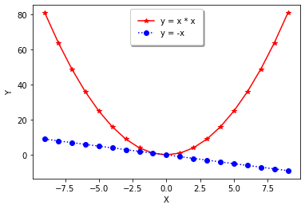

```python
import matplotlib.pyplot as plt
import numpy as np

x = np.arange(-9,10)
y1 = x ** 2
y2 = -x
plt.plot(x, y1, linestyle = "-", marker="*", color="red", label="y = x * x")
plt.plot(x, y2, linestyle = ":", marker="o", color="blue", label="y = -x")
plt.xlabel("X")
plt.ylabel("Y")
plt.legend(shadow=True, borderpad=1)
plt.show()
```